[figure not shown]

# KBC Academy

### Topics in Advanced Machine Learning

## About the course

#### - Experience sharing - discussions are welcomed - conceptual knowledge and practical skills - not too academic style - designing and applying techniques for modeling complex systems - significant body of knowledge - most is for self-prepare - focus on specific topics of interest, proposed by the KBC institution - adaptive to the needs of the audience

#### - platform-agnostic - understanding the concepts and not on particular software implementations - Flipped classroom, the learners are expected to be: * preparing for lectures preliminarily (out-of-class activity); * participating actively in the discussions during the lectures (in-class activity) * Phase 3 is optional time for exercising the new techniques (4 weeks) - self learning.

# Feature engineering for structured data

### Angel Marchev, Jr.

### Special guest: Alexander Efremov

### Agenda

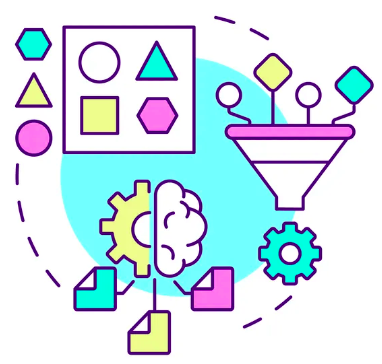

1. Workflow review
2. Preliminary remarks
3. Feature engineering in Panel data
4. Feature engineering in Time series data
5. Variable reduction
6. Regularization
7. Factor analysis

### Workflow 1/3

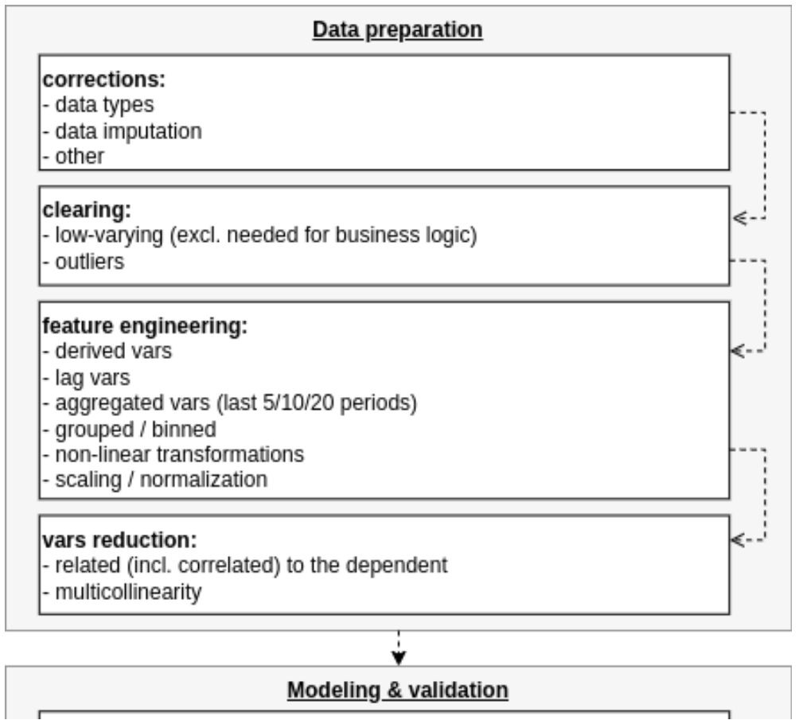

### Workflow 2/3

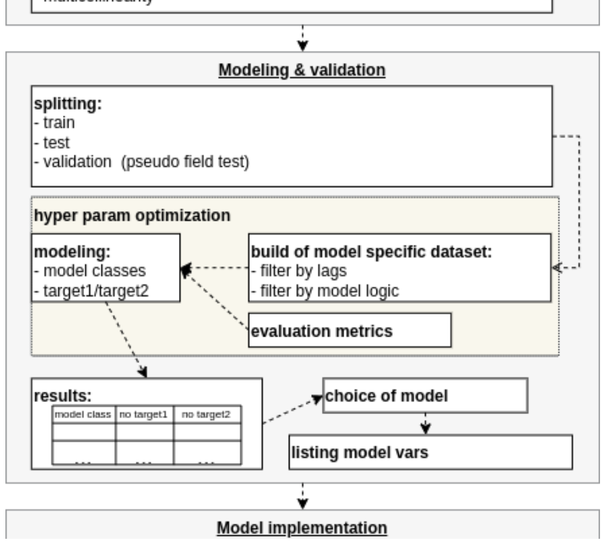

### Workflow 3/3

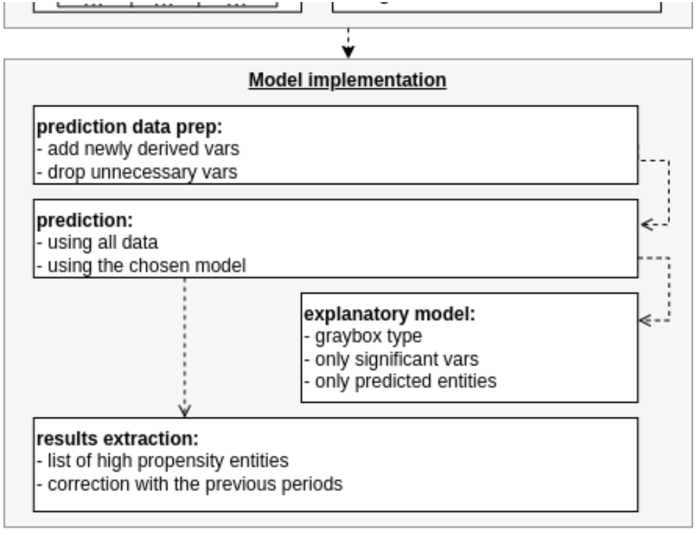

## Preliminary remarks

- **Data uncertainty**
  - A larger sample size can help (central limit theorem)
  - but cannot eliminate it completely
  - Feature engineering (along with other data prep) can also introduce additional sources of error and bias.
  - "Smarter" than data mining

## Preliminary remarks

- With panel data if possible **pivot datetime features** as a single time index
  - 1NF normalization
  - have power of TS analysis available

```
SELECT id, date, value
FROM my_table
UNPIVOT (value FOR date IN (' + @cols + ')) AS unpivoted'
```

```
    my_table:
    id   date1        date2        date3
    1    2022-01-01  2022-02-01  2022-03-01
    2    2022-04-01  2022-05-01  2022-06-01
            |
            V
    id   date   value
    1    date1  2022-01-01
    1    date2  2022-02-01
    1    date3  2022-03-01
    2    date1  2022-04-01
    2    date2  2022-05-01
    2    date3  2022-06-01
```

## Feature engineering in Panel data

**Process of selecting and transforming raw data into features that can be used to train machine learning models.**

**Most often operations**

- outliers detection & manipulation
- reduce low varying features
- derive domain/task specific features
- re-scaling
- non-linear transformations
- encoding
- binning

## Outliers detection & manipulation

- **Z-score**
  - assumes normal distribution
  - may not work well if it is significantly different (i.e., if the outliers have a different mean and standard deviation)

```python
# detect outliers using z-score
z_scores = (df - df.mean()) / df.std()
threshold = 3
outliers = np.abs(z_scores) > threshold
detected_out=df[outliers]

# remove outliers from the data
clean_data = df[~outliers]

# replace outliers with mean value
mean_value = df.mean()
df[outliers] = np.tile(mean_value.values, (len(df[outliers].index), 1))
```

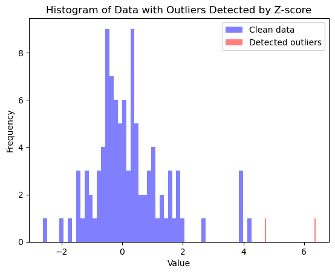

```python
fig, ax = plt.subplots()
# plot histogram of clean data in blue
ax.hist(clean_data, bins=50, color='blue', alpha=0.5, label='Clean data')
# plot histogram of detected outliers in red
ax.hist(detected_out, bins=50, color='red', alpha=0.5, label='Detected outliers')
ax.set_xlabel('Value')
ax.set_ylabel('Frequency')
ax.set_title('Histogram of Data with Outliers Detected by Z-score')
ax.legend()
plt.show()
```

## Outliers detection & manipulation

- **Interquartile range (IQR)**
  - more robust to non-normal distributions
  - defined as the difference between the 75th and 25th percentiles of the data
  - IQR is less sensitive to extreme values than the standard deviation

```python
# detect outliers using IQR
Q1 = df['Value'].quantile(0.25)
Q3 = df['Value'].quantile(0.75)
IQR = Q3 - Q1
outliers = (df['Value']<Q1 - 1.5 * IQR) | (df['Value']>Q3 + 1.5 * IQR)
detected_out=df[outliers]

# remove outliers from the data
clean_data = df[~outliers]

# replace outliers with mean value + noise
mean_value = df.mean()
noise = np.random.normal(0, 0.1, len(df[outliers]))
mean_value_with_noise = noise + mean_value.item()

# tile mean value with noise to replace outliers
df[outliers] = pd.DataFrame(mean_value_with_noise, columns=['Value'])
```

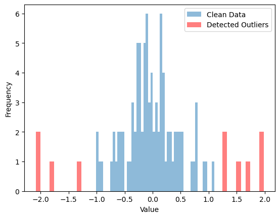

```python
# plot histogram with 50 bins
plt.hist(df['Value'], bins=50, alpha=0.5)
# plot detected outliers in red
plt.hist(detected_out['Value'], bins=50, color='red', alpha=0.5)
# set plot labels and legend
plt.xlabel('Value')
plt.ylabel('Frequency')
plt.legend(['Clean Data', 'Detected Outliers'])
# show plot
plt.show()
```

## Reduce low varying features

- features with low variance
- do not contribute much to the prediction (can even degrade the performance)
- identify by calculating the variance of each feature, and removing the features with variance less than a threshold.

```python
import pandas as pd
import numpy as np
# create sample dataframe
data = {'A': [1, 2, 3, 4, 5],
        'B': [1, 1, 1, 1, 1],
        'C': [1, 1, 2, 1, 1],
        'D': [1, 2, 3, 2, 1],
        'E': [1, 1, 1, 1, 1]}
df = pd.DataFrame(data)

# calculate coefficient of variation for each column
cv = df.std() / df.mean()
# define threshold for coefficient of variation
threshold = 0.1

# identify low varying variables
low_var = cv < threshold
# remove low varying variables from the dataframe
clean_data = df.drop(columns=df.columns[low_var])
```

```python
# print the results
print('Original data:\n', df)
print('Cleaned data:\n', clean_data)
```

```
Original data:
    A  B  C  D  E
0  1  1  1  1  1
1  2  1  1  2  1
2  3  1  2  3  1
3  4  1  1  2  1
4  5  1  1  1  1
Cleaned data:
    A  C  D
0  1  1  1
1  2  1  2
2  3  2  3
3  4  1  2
4  5  1  1
```

## Derive domain/task specific features

- creating features that are specific to the problem domain
- need for domain knowledge

```python
import pandas as pd

# create sample dataframe
data = {'Company': ['A', 'B', 'C', 'D'],
        'Revenue': [100000, 50000, 75000, 125000],
        'COGS': [70000, 25000, 50000, 80000],
        'EBITDA': [30000, 25000, 25000, 45000]}
df = pd.DataFrame(data)

# calculate financial ratios
df['Gross Profit'] = df['Revenue'] - df['COGS']
df['Gross Margin'] = df['Gross Profit'] / df['Revenue']
df['EBITDA Margin']= df['EBITDA'] / df['Revenue']
df['Net Income'] = df['EBITDA'] - (df['COGS'] - (df['COGS'] / df['Revenue']) * df['EBITDA'])
df['Net Margin'] = df['Net Income'] / df['Revenue']
df['ROE'] = df['Net Income'] / (df['COGS'] + df['EBITDA'])
df['ROA'] = df['Net Income'] / df['Revenue']

df[['Gross Margin','EBITDA Margin', 'Net Income','Net Margin','ROE', 'ROA']] = df[['Gross Margin','EBITDA Margin', 'Net Income','Net Margin','ROE', 'ROA']].round(2)
```

```python
# print the results
df
```

|  | Company | Revenue | COGS | EBITDA | Gross Profit | Gross Margin | EBITDA Margin | Net Income | Net Margin | ROE | ROA |
| --- | --- | --- | --- | --- | --- | --- | --- | --- | --- | --- | --- |
| 0 | A | 100000 | 70000 | 30000 | 30000 | 0.30 | 0.30 | -19000.00 | -0.19 | -0.19 | -0.19 |
| 1 | B | 50000 | 25000 | 25000 | 25000 | 0.50 | 0.50 | 12500.00 | 0.25 | 0.25 | 0.25 |
| 2 | C | 75000 | 50000 | 25000 | 25000 | 0.33 | 0.33 | -8333.33 | -0.11 | -0.11 | -0.11 |
| 3 | D | 125000 | 80000 | 45000 | 45000 | 0.36 | 0.36 | -6200.00 | -0.05 | -0.05 | -0.05 |

## Re-scaling

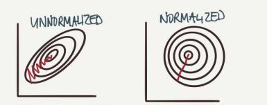

- **Scaling**
  - bring all variables to a similar scale, which can improve the performance of certain algorithms.
  - helps to reduce the effect of outliers
  - can improve the interpretability of the data
  - Could mean several different operations
- **Normalization**
  - scaling the data so that all values are between 0 and 1.
  - useful for datasets with varying ranges
  - when it is important to maintain the relative differences between the values.
- **Standardization**
  - scaling the data so that the mean is 0 and the standard deviation is 1
  - useful for datasets with normally distributed variables
  - when it is important to maintain the shape of the distribution.
- **Centering**
  - shifting the data so that the mean is 0
  - useful for datasets where the absolute value of the data is not important, but the relative differences between the values are

```python
# apply different scaling techniques
scalers = {'Min-Max': MinMaxScaler(),
           'Standard': StandardScaler()}
```

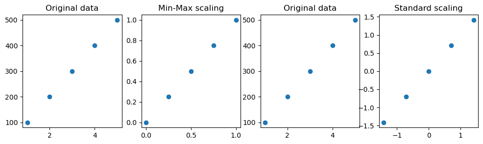

```python
fig, axs = plt.subplots(1, len(scalers)*2, figsize=(12, 3))

for i, (scaler_name, scaler) in enumerate(scalers.items()):
    # fit and transform the data using the scaler
    scaled_data = scaler.fit_transform(df)
    scaled_df = pd.DataFrame(scaled_data, columns=df.columns)

    # plot the original data
    axs[i*2].scatter(df['A'], df['B'])
    axs[i*2].set_title('Original data')

    # plot the scaled data
    axs[i*2+1].scatter(scaled_df['A'], scaled_df['B'])
    axs[i*2+1].set_title(scaler_name + ' scaling')
```

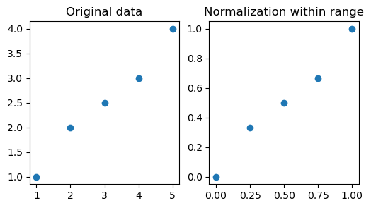

```python
# apply normalization within range
range_scaler = lambda x: (x - x.min()) / (x.max() - x.min())
scaled_data = df.apply(range_scaler)
scaled_df = pd.DataFrame(scaled_data, columns=df.columns)

# plot the results
fig, axs = plt.subplots(1, 2, figsize=(6, 3))
axs[0].scatter(df['A'], df['C'])
axs[0].set_title('Original data')
axs[1].scatter(scaled_df['A'], scaled_df['C'])
axs[1].set_title('Normalization within range')
plt.show()
```

## Non-linear transformations

- **transforms based on linearity by parameters**

| linear (lin) | logarithmic (lgn) | exponential (xpy) | power (pow) |
| --- | --- | --- | --- |
| $$Y=a_0+a_1.X$$ | $$Y=a_0+a_1.\ln{X}$$ $$Z=\ln{X}$$ $$Y=a_0+a_1.Z$$ | $$Y=e^{a_0+a_1.X}$$ $$Q=\ln{Y}$$ $$Q=a_0+a_1.X$$ | $$Y=a_0.X^{a_1}$$ $$Z=\ln{X}$$ $$Q=\ln{Y}$$ $$Q=a_0+a_1.Z$$ |
| reciprocal (rex) | reverse reciprocal (rey) | quadratic sum (sqr) | sine (snx) |
| $$Y=a_0+\frac{a_1}{X}$$ $$Z=\frac{1}{𝑋}, {X}\neq{0}$$ $$Y=a_0+a_1.Z$$ | $$Y=\frac{1}{a_0+a_1.X}$$ $$Q=\frac{1}{Y}, {Y}\neq{0}$$ $$Q=a_0+a_1.X$$ | $$Y={(a_0+a_1.X)^2}$$ $$Q=\sqrt{Y}$$ $$Q=\|a_0+a_1.X\|$$ | $${Y=a_0+a_1.\sin{X}}$$ $$Z=\sin{X}$$ $$Y=a_0+a_1.Z$$ |

```python
# Calculate the natural logarithm of the feature
data['Log_Feature'] = np.log(data['Feature'])

# Calculate the reciprocal of the feature
data['Reciprocal_Feature'] = 1 / data['Feature']

# Calculate the square root of the feature
data['Sqrt_Feature'] = np.sqrt(data['Feature'])

# Calculate the sine of the feature
data['Sin_Feature'] = np.sin(data['Feature'])
```

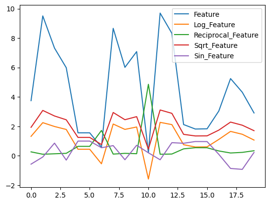

```python
# Create a scatter plot of all features
fig, ax = plt.subplots()
ax.plot(data.index, data['Feature'], label='Feature')
ax.plot(data.index, data['Log_Feature'], label='Log_Feature')
ax.plot(data.index, data['Reciprocal_Feature'], label='Reciprocal_Feature')
ax.plot(data.index, data['Sqrt_Feature'], label='Sqrt_Feature')
ax.plot(data.index, data['Sin_Feature'], label='Sin_Feature')
ax.legend()
plt.show()
```

## Encoding

**Convert categorical features into numerical features**

- **One-hot encoding**
  - create a new column for each category in the categorical variable, and setting the value to 1 if the category is present, and 0 otherwise.
  - could be modified for economical representation

```python
import pandas as pd
from sklearn.preprocessing import OneHotEncoder

# create sample dataframe
data = {'color': ['red', 'blue', 'green', 'red', 'green', 'blue'],
        'size': ['small', 'medium', 'small', 'large', 'medium', 'large']}
df = pd.DataFrame(data)
```

```python
# one-hot encode the categorical variables
onehot_encoder = OneHotEncoder()
onehot_encoded = onehot_encoder.fit_transform(df[['color', 'size']])
onehot_encoded = onehot_encoded.astype(int)  # convert to integers
onehot_df = pd.DataFrame(onehot_encoded.toarray(), columns=onehot_encoder.get_feature_names_out(['color', 'size']))

# concatenate the one-hot encoded data to the original dataframe
df = pd.concat([df, onehot_df], axis=1)
```

```python
# drop the original categorical variables
df.drop(['color', 'size'], axis=1, inplace=True)
# drop redundant ctegories
# df.drop(['color_red', 'size_small'], axis=1, inplace=True)
df
```

|  | color_blue | color_green | color_red | size_large | size_medium | size_small |
| --- | --- | --- | --- | --- | --- | --- |
| 0 | 0 | 0 | 1 | 0 | 0 | 1 |
| 1 | 1 | 0 | 0 | 0 | 1 | 0 |
| 2 | 0 | 1 | 0 | 0 | 0 | 1 |
| 3 | 0 | 0 | 1 | 1 | 0 | 0 |
| 4 | 0 | 1 | 0 | 0 | 1 | 0 |
| 5 | 1 | 0 | 0 | 1 | 0 | 0 |

## Encoding

- **Encoding with dependent mean**
  - can be useful in situations where there is a clear relationship between the categorical variable and the target variable
  - it can introduce bias in the data if the relationship between the categorical variable and the target variable is not well understood.

```python
# calculate mean price for each color
color_mean = df.groupby('color')['price'].mean()

# create new column with encoded values
df['color_mean'] = df['color'].map(color_mean)

# drop the original categorical variable
df.drop(['color'], axis=1, inplace=True)

print(df)
```

```
     size  price  color_mean
0   small     10        17.5
1  medium     20        21.0
2   small     15        16.5
3   large     25        17.5
4  medium     18        16.5
5   large     22        21.0
```

## Encoding

- **Weight of Evidence**
  - can be useful in situations where there is a non-linear relationship between the categorical variable and the target variable
  - it can introduce bias in the data if the relationship between the categorical variable and the target variable is not well understood.

```python
# calculate total counts and target counts for each category
total_counts = df.groupby('color')['target'].count()
target_counts = df.groupby('color')['target'].sum()
# calculate percentages and WoE values for each category
total_perc = total_counts / total_counts.sum()
target_perc = target_counts / target_counts.sum()
nontarget_perc = (total_counts - target_counts) / (total_counts.sum() - target_counts.sum())
woe_values = np.log(target_perc / nontarget_perc)
```

```python
print(df)
```

```
     size  target  color_woe
0   small      10   0.002018
1  medium      20   0.020861
2   small      31  -0.013730
3   large      22   0.002018
4  medium      11  -0.013730
5   large       5   0.020861
```

## Binning

**Convert numerical/categorical features into categorical features**

- **Unsupervised**
  - useful in situations where the data does not have a clear relationship with the target variable
  - can lead to biased results if the bin sizes are not chosen carefully
- **Supervised**
  - useful when there is a clear relationship between the numerical variable and the target variable
  - requires labeled data to train the classifier

```python
# unsupervised binning using equal width intervals
num_bins = 3
bin_labels = ['low', 'medium', 'high']
df['age_bins_unsupervised'] = pd.cut(df['age'], num_bins, labels=bin_labels)

# supervised binning using decision tree
tree = DecisionTreeClassifier(max_depth=1)
y = df['income']
X = df[df.columns.difference(['income','age_bins_unsupervised'])]
tree.fit(X, y)
df['age_bins_supervised'] = tree.predict(X)

ct = pd.crosstab(df['age_bins_supervised'], df['age_bins_unsupervised'])
ct
```

| age_bins_unsupervised age_bins_supervised | low | medium | high |
| --- | --- | --- | --- |
| 28800 | 14 | 50 | 0 |
| 53039 | 0 | 8 | 28 |

## Feature engineering in Time series

**Most often operations**

- lags
- rolling window statistics
- datetime
- outliers low frequency filter
- Harmonic decomposition

## Deriving lagged variables

**Variables with a time delay compared to the others. Variable shifted in time.**

- used in time series analysis to model the relationships between variables over time
- used to analyze the relationship between a variable and its past values

**Methods**

- **shift function in pandas**
- **Henkel matrix** - Strongly recommended universal method

```python
# create a lagged variable with a time shift of 1 day
df['lagged'] = df['value'].shift(1)

print(df)
```

```
   value  lagged
0      1     NaN
1      2     1.0
2      3     2.0
3      4     3.0
4      5     4.0
```

```python
import numpy as np

# Generate random time series data with 20 observations
data = np.random.rand(20)

# Define the maximum lag we want to include in our lagged features
max_lag = 5

# Create a Henkel matrix with lagged features
henkel_matrix = np.zeros((len(data), max_lag+1))

for i in range(max_lag+1):
    henkel_matrix[i:len(data), i] = data[0:len(data)-i]
henkel_matrix=henkel_matrix.round(3)
```

```python
# Print the Henkel matrix
print(henkel_matrix)
```

```
[[0.74  0.    0.    0.    0.    0.   ]
 [0.497 0.74  0.    0.    0.    0.   ]
 [0.586 0.497 0.74  0.    0.    0.   ]
 [0.061 0.586 0.497 0.74  0.    0.   ]
 [0.617 0.061 0.586 0.497 0.74  0.   ]
 [0.657 0.617 0.061 0.586 0.497 0.74 ]
 [0.859 0.657 0.617 0.061 0.586 0.497]
 [0.569 0.859 0.657 0.617 0.061 0.586]
 [0.905 0.569 0.859 0.657 0.617 0.061]
 [0.834 0.905 0.569 0.859 0.657 0.617]
 [0.568 0.834 0.905 0.569 0.859 0.657]
 [0.847 0.568 0.834 0.905 0.569 0.859]
 [0.026 0.847 0.568 0.834 0.905 0.569]
 [0.818 0.026 0.847 0.568 0.834 0.905]
 [0.961 0.818 0.026 0.847 0.568 0.834]
 [0.207 0.961 0.818 0.026 0.847 0.568]
 [0.57  0.207 0.961 0.818 0.026 0.847]
 [0.954 0.57  0.207 0.961 0.818 0.026]
 [0.237 0.954 0.57  0.207 0.961 0.818]
 [0.474 0.237 0.954 0.57  0.207 0.961]]
```

## Rolling window statistics

**Sample windows**

- used in time series analysis to reduce the dimensionality of the data
- capture relevant patterns over a specific time interval

**Method**

- defining a fixed-length sample window
- extract a set of features from each window
- size of the sample window is an important hyperparameter
- it should be chosen based on the characteristics of the time series data and the specific prediction problem at hand.

```python
# Define the window size for the rolling statistics
window_size = 3
# Calculate rolling mean, standard deviation, and maximum
rolling_mean = series.rolling(window_size).mean()
rolling_std = series.rolling(window_size).std()
rolling_max = series.rolling(window_size).max()
```

```python
df
```

|  | Original data | Rolling mean | Rolling standard deviation | Rolling maximum |
| --- | --- | --- | --- | --- |
| 0 | 0.076313 | NaN | NaN | NaN |
| 1 | 0.264040 | NaN | NaN | NaN |
| 2 | 0.675782 | 0.338712 | 0.306631 | 0.675782 |
| 3 | 0.068876 | 0.336233 | 0.309826 | 0.675782 |
| 4 | 0.806467 | 0.517042 | 0.393585 | 0.806467 |
| 5 | 0.705469 | 0.526937 | 0.399894 | 0.806467 |
| 6 | 0.756620 | 0.756185 | 0.050500 | 0.806467 |
| 7 | 0.018057 | 0.493382 | 0.412437 | 0.756620 |
| 8 | 0.089027 | 0.287901 | 0.407471 | 0.756620 |
| 9 | 0.579511 | 0.228865 | 0.305734 | 0.579511 |
| 10 | 0.527292 | 0.398610 | 0.269375 | 0.579511 |
| 11 | 0.970188 | 0.692330 | 0.242044 | 0.970188 |
| 12 | 0.485930 | 0.661137 | 0.268444 | 0.970188 |
| 13 | 0.957106 | 0.804408 | 0.275888 | 0.970188 |
| 14 | 0.128065 | 0.523700 | 0.415809 | 0.957106 |
| 15 | 0.372937 | 0.486036 | 0.425935 | 0.957106 |
| 16 | 0.881238 | 0.460746 | 0.384188 | 0.881238 |
| 17 | 0.867801 | 0.707325 | 0.289667 | 0.881238 |
| 18 | 0.971188 | 0.906742 | 0.056215 | 0.971188 |
| 19 | 0.874550 | 0.904513 | 0.057841 | 0.971188 |

## Datetime index operations

**Re-scaling**

- manipulating the index of DataFrame to a new scale of dates

```python
import pandas as pd

# create a DataFrame with a datetime index
date_rng = pd.date_range(start='1/1/2020', end='1/20/2020', freq='D')
df = pd.DataFrame(date_rng, columns=['date'])
df['data'] = np.random.randint(0,100,size=(len(date_rng)))

# change the frequency to weekly and take the mean of each group
df = df.set_index('date')
weekly_df = df.resample('W').mean()
weekly_df
```

| date | data |
| --- | --- |
| 2020-01-05 | 59.600000 |
| 2020-01-12 | 70.857143 |
| 2020-01-19 | 42.857143 |
| 2020-01-26 | 95.000000 |

## Datetime index operations

**Re-framing**

- fill in the missing dates with some specified fill value.

```python
# fill in the missing dates with NaN values
df = df.set_index('date')
df_new = df.asfreq('D')
df_new
```

| date | data |
| --- | --- |
| 2020-01-01 | 54.0 |
| 2020-01-02 | 67.0 |
| 2020-01-03 | 42.0 |
| 2020-01-04 | NaN |
| 2020-01-05 | 60.0 |
| 2020-01-06 | 22.0 |
| 2020-01-07 | 99.0 |

## Datetime index operations

**Extracting datetime features**

- using the full datetime string to brake down into features

```python
# Convert the data to a Pandas Series with DatetimeIndex
series = pd.Series(data, index=date_range)

# Extract calendar and time base features from the index
year = series.index.year
month = series.index.month
day = series.index.day
hour = series.index.hour
minute = series.index.minute
```

```python
df
```

|  | Date | Data | Year | Month | Day | Hour | Minute |
| --- | --- | --- | --- | --- | --- | --- | --- |
| 0 | 2022-01-01 00:00:00 | 0.114295 | 2022 | 1 | 1 | 0 | 0 |
| 1 | 2022-01-01 01:00:00 | 0.499400 | 2022 | 1 | 1 | 1 | 0 |
| 2 | 2022-01-01 02:00:00 | 0.316746 | 2022 | 1 | 1 | 2 | 0 |
| 3 | 2022-01-01 03:00:00 | 0.901192 | 2022 | 1 | 1 | 3 | 0 |
| 4 | 2022-01-01 04:00:00 | 0.531030 | 2022 | 1 | 1 | 4 | 0 |
| 5 | 2022-01-01 05:00:00 | 0.792617 | 2022 | 1 | 1 | 5 | 0 |
| 6 | 2022-01-01 06:00:00 | 0.100412 | 2022 | 1 | 1 | 6 | 0 |
| 7 | 2022-01-01 07:00:00 | 0.187317 | 2022 | 1 | 1 | 7 | 0 |
| 8 | 2022-01-01 08:00:00 | 0.786790 | 2022 | 1 | 1 | 8 | 0 |
| 9 | 2022-01-01 09:00:00 | 0.497147 | 2022 | 1 | 1 | 9 | 0 |
| 10 | 2022-01-01 10:00:00 | 0.138009 | 2022 | 1 | 1 | 10 | 0 |
| 11 | 2022-01-01 11:00:00 | 0.681217 | 2022 | 1 | 1 | 11 | 0 |
| 12 | 2022-01-01 12:00:00 | 0.251439 | 2022 | 1 | 1 | 12 | 0 |
| 13 | 2022-01-01 13:00:00 | 0.518483 | 2022 | 1 | 1 | 13 | 0 |
| 14 | 2022-01-01 14:00:00 | 0.559895 | 2022 | 1 | 1 | 14 | 0 |
| 15 | 2022-01-01 15:00:00 | 0.542000 | 2022 | 1 | 1 | 15 | 0 |
| 16 | 2022-01-01 16:00:00 | 0.265538 | 2022 | 1 | 1 | 16 | 0 |
| 17 | 2022-01-01 17:00:00 | 0.068318 | 2022 | 1 | 1 | 17 | 0 |
| 18 | 2022-01-01 18:00:00 | 0.548399 | 2022 | 1 | 1 | 18 | 0 |
| 19 | 2022-01-01 19:00:00 | 0.909004 | 2022 | 1 | 1 | 19 | 0 |

## Outliers low frequency filter

- Similar to panel data case
- but it could be implemented to be a streaming process
- IQR

```python
# Convert the data to a Pandas Series
series = pd.Series(data)

# Calculate the first and third quartiles
q1 = series.quantile(0.25)
q3 = series.quantile(0.75)

# Define the filter based on the interquartile range (IQR)
iqr = q3 - q1
filter = (series >= q1 - 1.5*iqr) & (series <= q3 + 1.5*iqr)

# Filter the data
filtered_data = series[filter]
```

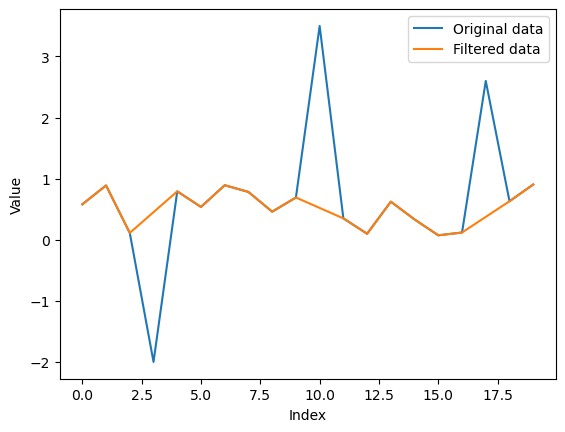

```python
# Plot the original data and the filtered data
fig, ax = plt.subplots()
ax.plot(series.index, series.values, label='Original data')
ax.plot(filtered_data.index, filtered_data.values, label='Filtered data')
ax.set_xlabel('Index')
ax.set_ylabel('Value')
ax.legend()
plt.show()
```

## Harmonics decomposition

**Extract seasonality from a time series, decomposing them into its trend, seasonal, and residual components.**

**Fourier**

- Decompose a signal into its frequency components
- based on the Fourier series
- any periodic function can be represented as a sum of sine and cosine waves of different frequencies, phases, and amplitudes
- the time series data is first transformed into the frequency domain using a Fourier transform
- The amplitudes and phases of these waves are then estimated using a least-squares regression

```python
display(iframe)
```

[interactive chart not shown]

```python
# Calculate the Fourier coefficients for each harmonic separately
num_harmonics = 3
all_coeffs = np.fft.fft(series)
coeffs = []
for i in range(1, num_harmonics+1):
    coeffs.append(np.zeros(len(all_coeffs), dtype=complex))
    coeffs[-1][i] = all_coeffs[i]
    coeffs[-1][-i] = all_coeffs[-i]

# Reconstruct the signal using the first 3 harmonics
reconstructed_coeffs = np.zeros(len(all_coeffs), dtype=complex)
for i in range(num_harmonics):
    reconstructed_coeffs += coeffs[i]
reconstructed_signal = np.fft.ifft(reconstructed_coeffs).real
reconstructed_signal += series.mean()
```

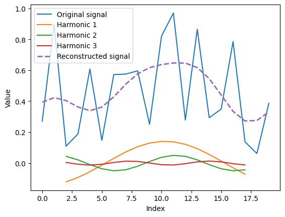

```python
# Plot the original signal and the reconstructed signals for each harmonic
fig, ax = plt.subplots()
ax.plot(series.index, series.values, label='Original signal')
for i in range(num_harmonics):
    smoothed_signal = pd.Series(np.fft.ifft(coeffs[i]).real, index=series.index).rolling(window=5, center=True).mean()
    ax.plot(series.index, smoothed_signal.values, label='Harmonic ' + str(i+1))
ax.plot(series.index, reconstructed_signal, label='Reconstructed signal', linewidth=2, linestyle='--')
ax.set_xlabel('Index')
ax.set_ylabel('Value')
ax.legend()
```

## Harmonics decomposition

**Seasonality analysis**

- uses the classical time series decomposition method based on moving averages

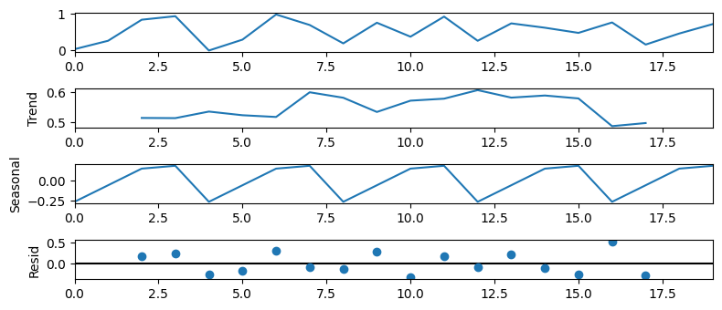

```python
# Perform the decomposition
decomposition = sm.tsa.seasonal_decompose(series, model='additive', period=4)

fig=decomposition.plot();
fig.set_size_inches((8, 3.5));
fig.tight_layout();
```

## Variables selection/reduction

**Selecting the most relevant features for the model, which can improve performance and reduce the risk of overfitting**

**X,X Correlation**

- Look for overlapping features
- Reduction method

```python
def hyperoptimize(corr_matrix, exclude_features):
    n_features = corr_matrix.shape[0]
    min_high_corr = float('inf')
    best_n_reduce = 0
    best_exclude = exclude_features.copy()

    for n_reduce in range(1, n_features):
        for k in range(n_features):
            for exclude in itertools.combinations(exclude_features, k):
                exclude = list(exclude)
                reduce_features = [i for i in range(n_features) if i not in exclude and i != n_reduce]
                reduced_corr_matrix = corr_matrix.iloc[reduce_features, reduce_features]
                n_high_corr = (reduced_corr_matrix.abs() > 0.5).sum().sum()
                if n_high_corr < min_high_corr:
                    min_high_corr = n_high_corr
                    best_n_reduce = n_reduce
                    best_exclude = exclude

    return best_n_reduce, best_exclude
```

```python
# Compute the correlation matrix
corr_matrix = df.corr()

# Store the initial correlation matrix
corr_matrix_old = df.corr()

# Set the threshold for the number of high-correlation values
threshold = 7

# Set the initial list of excluded features
exclude_features = []

# Iterate until the number of high-correlation values is below the threshold
while True:
    # Hyperoptimize the number of features to reduce and the excluded features
    n_reduce, exclude_features = hyperoptimize(corr_matrix, exclude_features)

    # Reduce the specified features
    reduce_features = [i for i in range(corr_matrix.shape[0]) if i not in exclude_features and i != n_reduce]
    corr_matrix = corr_matrix.iloc[reduce_features, reduce_features]

    # Count the number of high-correlation values
    n_high_corr = (corr_matrix.abs() > 0.5).sum().sum()

    # If the number of high-correlation values is below the threshold, break the loop
    if n_high_corr <= threshold:
        break
```

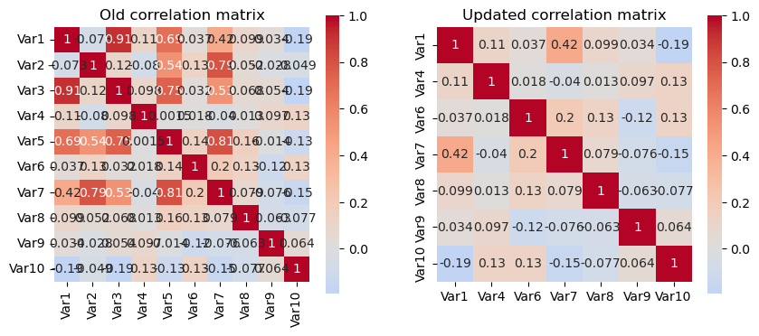

```python
# Create a figure with two axes side by side
fig, (ax1, ax2) = plt.subplots(ncols=2, figsize=(10, 4))

# Plot the first heatmap on the left axis
sns.heatmap(corr_matrix_old, annot=True, cmap='coolwarm', center=0, square=True, ax=ax1)
ax1.set_title('Old correlation matrix')

# Plot the second heatmap on the right axis
sns.heatmap(corr_matrix, annot=True, cmap='coolwarm', center=0, square=True, ax=ax2)
ax2.set_title('Updated correlation matrix')

# Show the plot
plt.show()
```

## Variables selection/reduction

**X,Y Correlation**

- Look for features with higher importance
- Selection method

```python
# Compute the correlation coefficients between the dependent variable and the independent variables
corr_matrix = df.corr().iloc[-1, :-1]
# Filter out the independent variables with low correlation coefficients
selected_vars = corr_matrix[corr_matrix.abs() >= 0.5].index
```

```python
print(corr_df)
```

```
       var      corr selected
0   Indep1  0.256760       no
1   Indep2  0.047934       no
2   Indep3  0.922601      yes
3   Indep4  0.147780       no
4   Indep5  0.891848      yes
5   Indep6  0.006403       no
6   Indep7  0.781090      yes
7   Indep8  0.066287       no
8   Indep9  0.013465       no
9  Indep10 -0.076730       no
```

## Multicollinearity

**Two or more predictor variables in a regression model are highly correlated, meaning they are linearly dependent on each other**

- can reduce the statistical significance of individual predictor variables
- lead to unstable and unreliable estimates of the regression coefficients
- makes it difficult to identify which predictor variables are actually contributing
- To address multicollinearity, variables can be removed or combined with other variables

```python
# display the IFrame object in the notebook output
display(iframe)
```

[interactive chart not shown]

## Multicollinearity

**Variance Inflation Factor (VIF)**

- a measure of multicollinearity in a multiple regression analysis.
- the ratio of the variance of the estimated coefficients of a variable in a regression model to the variance of the same coefficients in a model that does not include the variable.
- always greater than or equal to 1, and a value of 1 indicates that there is no correlation between the i-th variable and the other predictors in the model
- the greater than 1 the higher degree of correlation with one or more of the other predictors
- value of 5 or more is often used as a threshold for identifying variables with high multicollinearity

```python
# Compute the variance inflation factor for each variable
vif = pd.Series([variance_inflation_factor(df.values, i) for i in range(df.shape[1])],
                index=df.columns)

# Select the variables with VIF less than 5
selected_vars = vif[vif < 5].index
```

```python
# Print the VIF and the selected variables
print('Variance Inflation Factor:')
print(vif)
print('Selected variables:')
print(selected_vars)
```

```
Variance Inflation Factor:
Var1     39.607395
Var2     27.014129
Var3     31.176229
Var4      4.314400
Var5     32.245597
Var6      4.181100
Var7     40.196595
Var8      3.633429
Var9      4.434751
Var10     3.954685
dtype: float64
Selected variables:
Index(['Var4', 'Var6', 'Var8', 'Var9', 'Var10'], dtype='object')
```

## Regularization

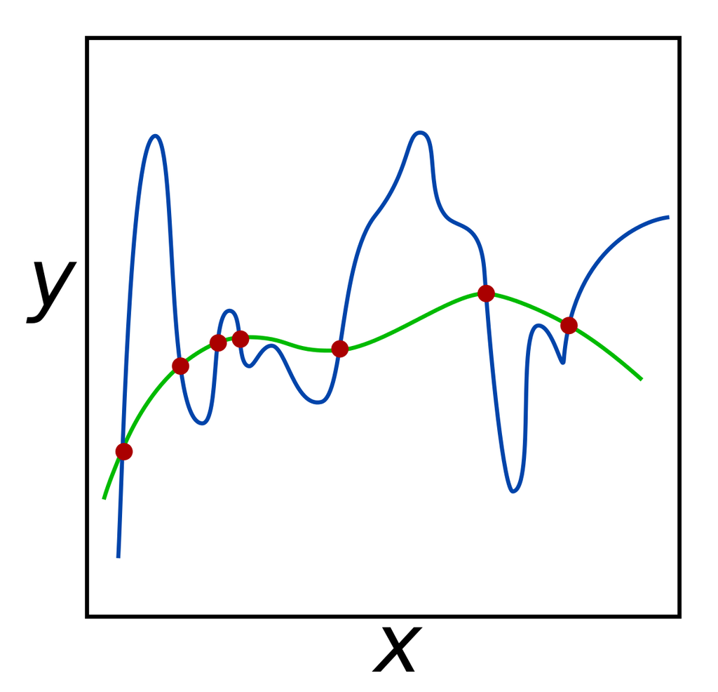

**Regularization is a technique to prevent overfitting and improve the performance of predictive models by adding a penalty term to the model.**

- shrinking the magnitude of the model parameters
- making them less sensitive to small changes in the input data
- encourages the model to produce simpler and more generalizable solutions
- ***advisible*** is using in combination with some cross-validation for easier hyperparameter optimization on the strength of the penalty term

## L1 Regularization

**L**east **A**bsolute **S**hrinkage and **S**election **O**perator adds a penalty term to the sum of squared errors (SSE) in the linear regression equation, using a tuning parameter to control the amount of regularization.

- shrinks the magnitude of the coefficients towards zero
- if effect - also variable selection (a more interpretable and efficient model)
- could solve the "large p, small n" problem
- could deal with multi-collinearity
- an optimization algorithm is used to minimize the objective function

$$ SSE_{{L1} norm} = min{(SSE + \lambda . \sum_{}|\beta_{i}|)}$$

where:

- SSE is the sum of squared errors
- λ is the tuning parameter
- βi are the coefficients of the predictor variables

```python
from sklearn.linear_model import Lasso
from sklearn.model_selection import train_test_split
from sklearn.metrics import mean_squared_error
```

```python
# Split the dataset into training and testing sets
X_train, X_test, y_train, y_test = train_test_split(dataset.data, dataset.target, test_size=0.2, random_state=42)

# Create a Lasso regression object with alpha=0.5
lasso_reg = Lasso(alpha=0.5)

# Fit the Lasso regression model to the training data
lasso_reg.fit(X_train, y_train)

# Use the trained model to make predictions on the testing data
y_pred = lasso_reg.predict(X_test)

# Calculate the mean squared error of the predictions
mse = mean_squared_error(y_test, y_pred)
```

```python
print("Mean Squared Error: ", mse)
df.round(2)
```

```
Mean Squared Error:  0.7263312822033787
```

|  | 0 | 1 | 2 | 3 | 4 | 5 | 6 | 7 | icpt |
| --- | --- | --- | --- | --- | --- | --- | --- | --- | --- |
| 0 | 0.29 | 0.01 | 0.0 | -0.0 | 0.0 | -0.0 | -0.0 | -0.0 | 0.59 |

[figure not shown]

```python
plot_lasso_coefs()
```

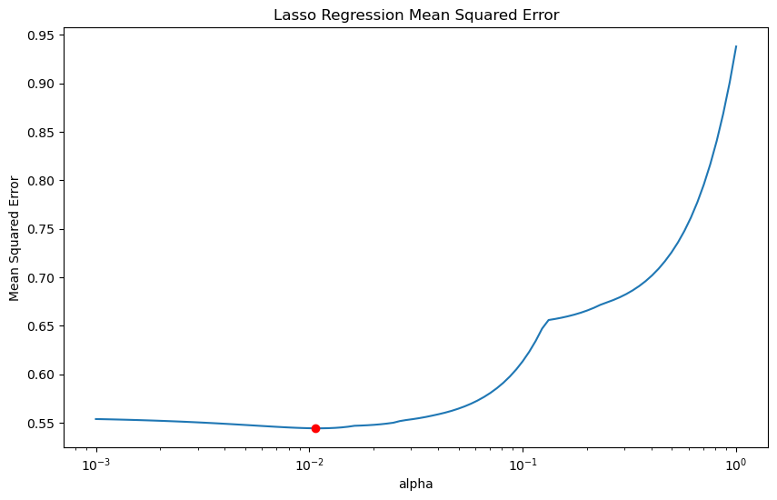

```python
plot_lasso_mse()
```

## L2 Regularization

**Ridge regression** adds a penalty term - proportional to the squared values of the model parameters.

- encourages to produce solutions with smaller parameter values
- often used to reduce the effects of collinearity by shrinking the coefficients of correlated variables towards each other
- can help prevent overfitting
- also shrinks the magnitude of the coefficients towards zero, but unlike lasso regression, it does not force any of the coefficients to be exactly zero
- can improve the stability and reduce the variance of the model without sacrificing too much in terms of bias.

$$ SSE_{{L2} norm} = min{(SSE + \lambda . \sum_{}\beta_{i}^2)}$$

where

- SSE is the sum of squared errors
- λ is the tuning parameter
- βi are the coefficients of the predictor variables

```python
from sklearn.linear_model import Ridge
from sklearn.model_selection import train_test_split
from sklearn.metrics import mean_squared_error
```

```python
# Split the dataset into training and testing sets
X_train, X_test, y_train, y_test = train_test_split(dataset.data, dataset.target, test_size=0.2, random_state=42)

# Create a Ridge regression object with alpha=0.5
ridge_reg = Ridge(alpha=0.5)

# Fit the Ridge regression model to the training data
ridge_reg.fit(X_train, y_train)

# Use the trained model to make predictions on the testing data
y_pred = ridge_reg.predict(X_test)

# Calculate the mean squared error of the predictions
mse = mean_squared_error(y_test, y_pred)
```

```python
print("Mean Squared Error: ", mse)
df.round(2)
```

```
Mean Squared Error:  0.5635171842142302
```

|  | 0 | 1 | 2 | 3 | 4 | 5 | 6 | 7 | icpt |
| --- | --- | --- | --- | --- | --- | --- | --- | --- | --- |
| 0 | 0.13 | 0.02 | 0.03 | -0.01 | -0.0 | -0.01 | -0.03 | -0.01 | 2.07 |

[figure not shown]

```python
plot_ridge_coefs()
```

[figure not shown]

```python
plot_ridge_mse()
```

## L1 & L2 Regularization

**Elastic net** is a regularization combining the L1 and L2 regularization techniques used in Lasso and Ridge regression.

- designed to overcome some of the limitations of Lasso and Ridge regression by leveraging their respective strengths
- L1 penalty tends to produce sparse solutions by setting some coefficients to zero
- L2 penalty tends to shrink the magnitude of the coefficients towards zero
- combines the strengths of Lasso and Ridge regression by adding a combination of the L1 and L2 penalties, shrinking the magnitude of the coefficients towards zero while also setting some of them to exactly zero.

$$SSE_{{L1}{L2} norm} = min{(SSE + \lambda_1 . \sum_{}|\beta_{i}| + \lambda_2 . \sum_{}\beta_{i}^2)}$$

where:

- SSE is the sum of squared errors
- λ1 and λ2 are the tuning parameters
- βi are the coefficients of the predictor variables

```python
from sklearn.linear_model import ElasticNet
from sklearn.model_selection import train_test_split
from sklearn.metrics import mean_squared_error
```

```python
# Split the dataset into training and testing sets
X_train, X_test, y_train, y_test = train_test_split(dataset.data, dataset.target, test_size=0.2, random_state=42)

# Create an Elastic Net object with alpha=0.5, l1_ratio=0.5
enet = ElasticNet(alpha=0.5, l1_ratio=0.5)

# Fit the Elastic Net model to the training data
enet.fit(X_train, y_train)

# Use the trained model to make predictions on the testing data
y_pred = enet.predict(X_test)

# Calculate the mean squared error of the predictions
mse = mean_squared_error(y_test, y_pred)
```

```python
print("Mean Squared Error: ", mse)
df.round(2)
```

```
Mean Squared Error:  0.6868730783041608
```

|  | 0 | 1 | 2 | 3 | 4 | 5 | 6 | 7 | icpt |
| --- | --- | --- | --- | --- | --- | --- | --- | --- | --- |
| 0 | 0.34 | 0.01 | -0.0 | 0.0 | 0.0 | -0.0 | -0.0 | -0.0 | 0.31 |

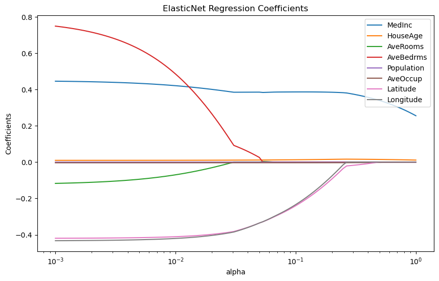

```python
plot_enet_coef_alpha()
```

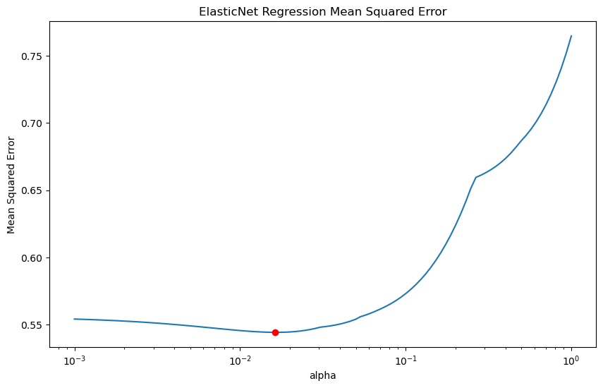

```python
plot_enet_mse_alpha()
```

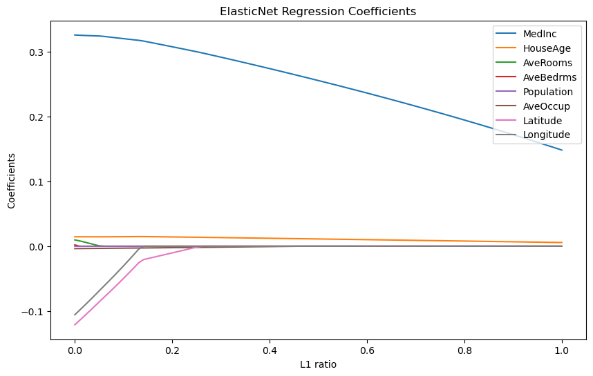

```python
 plot_enet_coef_l1ratio()
```

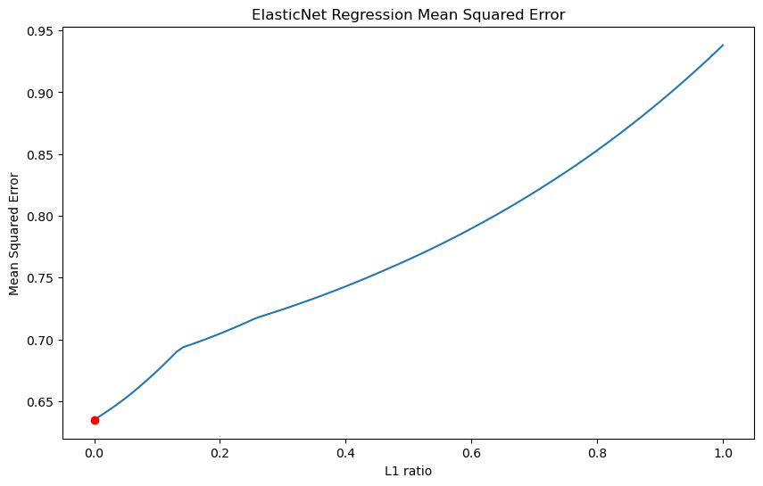

```python
plot_enet_mse_l1ratio()
```

## Factor analysis

Feature extraction: This involves transforming raw data into a new set of features that better capture the underlying patterns in the data. This can include techniques such as principal component analysis (PCA), singular value decomposition (SVD), Linear Discriminant Analysis (LDA), etc.